# ARIMA Assignment 6

Juan Romo

# Load Libraries

```r
library(fpp)
library(fpp2)
library(readxl)
```

# Load Data

```r
US_Nominal_GDP_NSA_Data <- read_excel("C:/Users/jprom/Desktop/Class Notes/Class Fall 2023/Business Forecasting/Week 9/HW Assignment 6 ARIMA/US Nominal GDP NSA Data.xlsx",
    sheet = "US Nominla GDP")

View(US_Nominal_GDP_NSA_Data)

# Create a copy of the data

US_GDP_df <- as.data.frame(US_Nominal_GDP_NSA_Data)
```

# Clean Up Data

```r
# Set Date a date format

US_GDP_df$Period <- as.Date(as.yearqtr(US_GDP_df$Period, format = "Q%q %Y", frac = 1))

head(US_GDP_df)
```

|  | Period | US_Nominal_GDP |
| --- | --- | --- |
| 1 | 2023-04-01 | 5569.5 |
| 2 | 2023-01-01 | 5415.4 |
| 3 | 2022-10-01 | 5596.5 |
| 4 | 2022-07-01 | 5487.0 |
| 5 | 2022-04-01 | 5434.7 |
| 6 | 2022-01-01 | 5303.8 |

```r
# Reverse Data Order

US_GDP_df <- US_GDP_df[order(US_GDP_df$Period, decreasing = FALSE),]

head(US_GDP_df)
```

|  | Period | US_Nominal_GDP |
| --- | --- | --- |
| 54 | 2010-01-01 | 4055.1 |
| 53 | 2010-04-01 | 4188.7 |
| 52 | 2010-07-01 | 4229.4 |
| 51 | 2010-10-01 | 4316.6 |
| 50 | 2011-01-01 | 4155.6 |
| 49 | 2011-04-01 | 4251.8 |

```r
# Covert to Time Series

GDP_Data <- ts(US_GDP_df$US_Nominal_GDP, start = c(2010,1), end = c(2023,2), frequency = 4)

str(GDP_Data)
```

```
 Time-Series [1:54] from 2010 to 2023: 4055 4189 4229 4317 4156 ...
```

# Plot Time Series

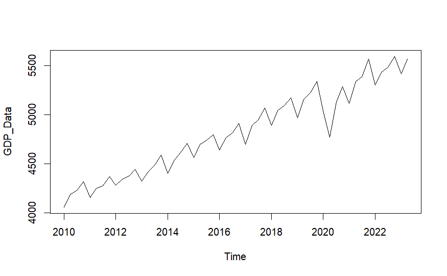

```r
plot(GDP_Data)
```

```r
# Subset Data Example

# Example subset the time series

#GDP_2 <- window(GDP_Data, start=c(2015, 1), end=c(2023, 2))

#plot(GDP_2)
```

# Observations:

- The data has clear upward trend, with a significat decline in 2020 due to the economic effects of the corona virus pandemic.
- The data also shows a seasonal pattern with well defined peaks and troughs that appear to repeat every 4 quarters.
- Although there was a decline in 2020 to 2021 it appears that the GDP recovered in recent years and reverting back to the trend observed in years prior to the pandemic. Therefore, it seems that it may not necessary to subset the data since the change was temporary and there were no structural changes to the data after the decline.

# Data Summary Statistics and Plots

```r
summary(GDP_Data)
```

```
   Min. 1st Qu.  Median    Mean 3rd Qu.    Max.
   4055    4424    4786    4819    5150    5596
```

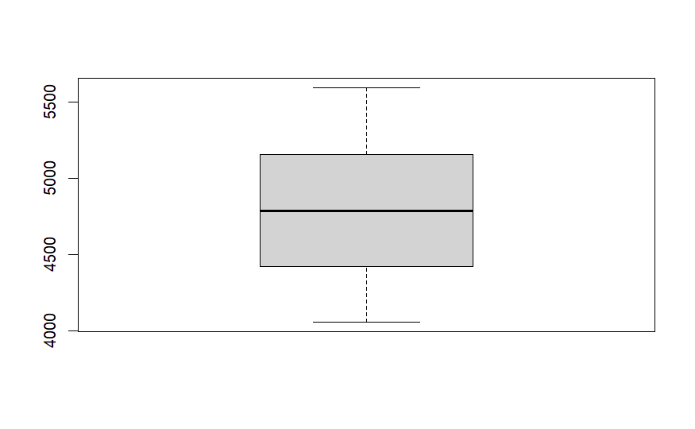

```r
boxplot(GDP_Data)
```

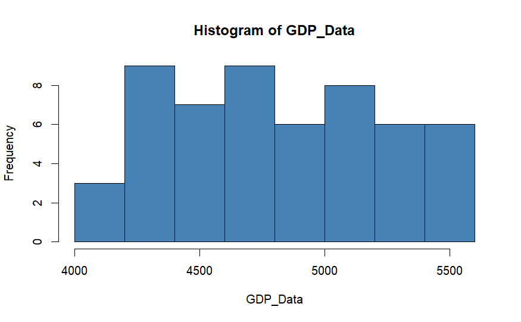

```r
hist(GDP_Data, breaks = 10, col = "SteelBlue")
```

```
[1] 52  1
```

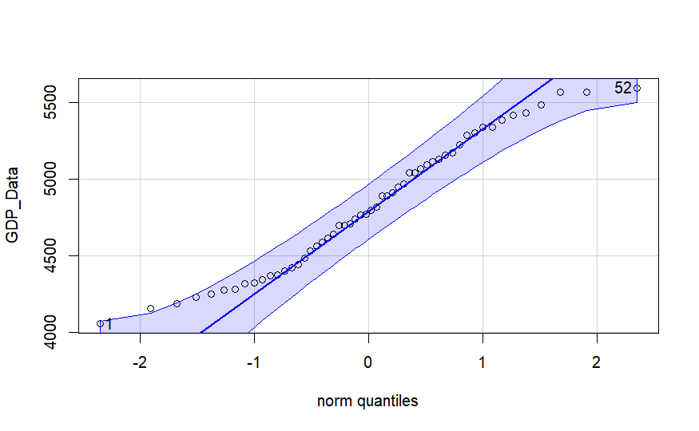

```r
# Plot QQ Plot of Data

# qqnorm(GDP_Data) - Works but shows no line

# qqline(GDP_Data, col = "Steelblue") - shows abline error

# Can use qqPlot() function in "car" package - to get same results as above.

library(car)

qqPlot(GDP_Data)
```

# Observations

- Descriptive statistics and plots above show that the GDP data is somewhat normally distributed, with the exception of around the tails which represent the early and recent years in the data.

# ACF Plot & PACF

- ACF plot gives you the gross correlation between the Y value and all its past values. -PACF plot gives you the simple correlation between Y value and its lags without the interaction of the intervening lags.
- ACF and PACT give can give you a sense or guide to as what are some plausible ARIMA models. They can help select the ARIMA P & Q values.
- P Value - tells you how many autoregressive lags to include in your model.
- Q Value - tells you how many lags of the residuals to include in your model - The Q value helps to account for the possibility of a relationship between Y variable and the residuals from past periods - it tries to find signals in the errors. The goal of the MA portion of the ARIMA model is to minimize the noise in the data.

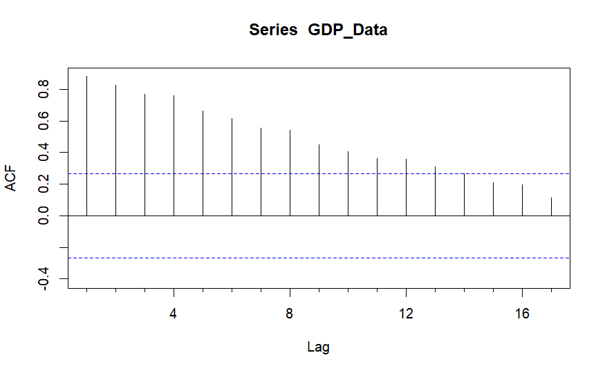

```r
# Use ACF plot to see if there is a trend or seasonality within the data.

Acf(GDP_Data)
```

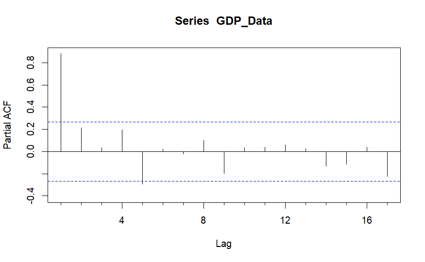

```r
# Plot PACF to see possible P value combinations to consider in the ARIMA model.

Pacf(GDP_Data)
```

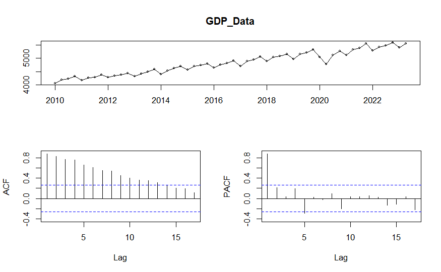

```r
# tsdisplay() function shows bot acf and pacf plots

tsdisplay(GDP_Data)
```

# Observations

# Use Decomposition to determine if there is seasonality

```r
GDP_Decomp <- decompose(GDP_Data)

GDP_Decomp
```

```
$x
       Qtr1   Qtr2   Qtr3   Qtr4
2010 4055.1 4188.7 4229.4 4316.6
2011 4155.6 4251.8 4273.2 4371.8
2012 4279.8 4345.7 4376.7 4440.6
2013 4320.3 4419.1 4486.4 4586.3
2014 4403.2 4532.3 4616.6 4709.6
2015 4562.4 4696.8 4741.1 4799.4
2016 4641.9 4768.3 4819.2 4912.3
2017 4698.4 4893.2 4950.9 5069.6
2018 4890.8 5040.0 5092.5 5170.6
2019 4968.9 5157.4 5223.9 5341.9
2020 5044.8 4773.3 5129.1 5286.9
2021 5116.1 5337.0 5386.2 5568.3
2022 5303.8 5434.7 5487.0 5596.5
```

[output cut: 61 more lines]

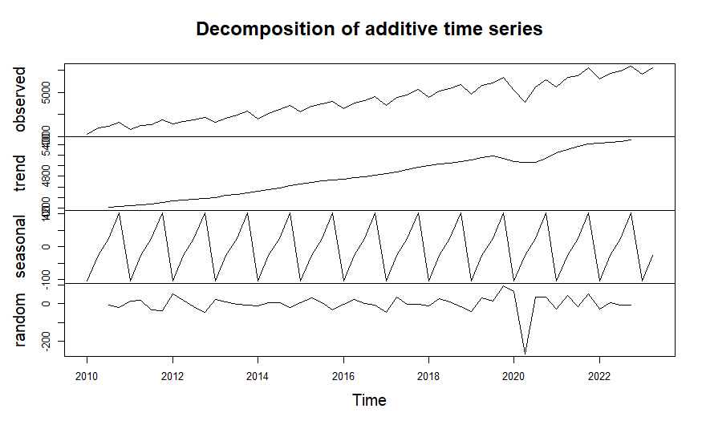

```r
plot(GDP_Decomp)
```

# Observations

- Decomposition of the GDP data shows there is a clear upward trend. Also there is some seasonality present in the data. However, the impact of that seasonality only ranges from -100 to +100 million per period.
- ARIMA model assumes data is stationary.Need to remove the trend from the data to make it stationary.
- Need to use differentiation to make the data stationary.

# Use differenation to make the data stationary

```r
# Use adf.test() function - Augmented Dickey Fuller Test tells you if the time series is stationary.
# Tests uses Null Hypothesis - Time series is non stationary & Alternative hypothesis - data is Stationary
# Data is non stationary if p value is less than significance level alpha. - reject the null hypothesis
# ADF test says differences is required if p-value is > 0.05

# Can also use Kipps test to determine if differencing is required.
# Kipps test says differences is required if p-value is < 0.05

library(tseries)

adf.test(GDP_Data)
```

```
    Augmented Dickey-Fuller Test

data:  GDP_Data
Dickey-Fuller = -2.553, Lag order = 3, p-value = 0.3518
alternative hypothesis: stationary
```

```r
kpss.test(GDP_Data)
```

```
    KPSS Test for Level Stationarity

data:  GDP_Data
KPSS Level = 1.4364, Truncation lag parameter = 3, p-value = 0.01
```

```r
# the ndiffs() function tells you the number of rounds needed to make the data stationary.
# ndiffs() works with non-seasonal data.

ndiffs(GDP_Data)
```

```
[1] 1
```

```r
# the nsdiffs() funtion tells you how many differences to you need
# nsdiffs() only workds for seasonal data.

nsdiffs(GDP_Data)
```

```
[1] 1
```

# Observations:

- adf test shoes p-value of 0.35 - means that we cannot reject the null hypothesis therefore the data is non stationary.
- ndiffs says we need to only do 1 round of differentiation to make the data stationary.
- nsdiffs says we need to do 1 round of differentiation to make the data stationary.
- *** Begin with seasonal differentiation since this may be enough to make the data stationary.

# Seasonal Differtiation

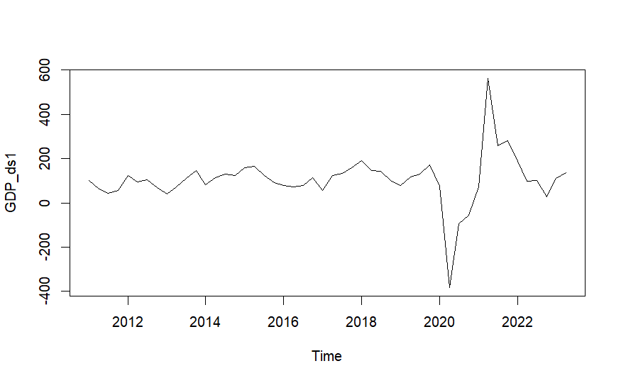

```r
# use diff() function to do differentiation
# the diff() parameter -> lag - is integer indicating which lag to use
# the diff() parameter -> differences - is the integer indicating the order of the differences
# Since the GDP data is quarter we must use a lag of 4

GDP_ds1 <- diff(GDP_Data,lag = 4, differences = 1)

plot(GDP_ds1)
```

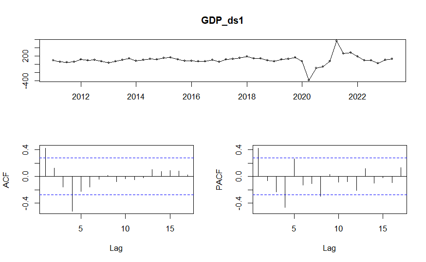

```r
tsdisplay(GDP_ds1)
```

```r
adf.test(GDP_ds1)
```

```
    Augmented Dickey-Fuller Test

data:  GDP_ds1
Dickey-Fuller = -5.7171, Lag order = 3, p-value = 0.01
alternative hypothesis: stationary
```

```r
# test - ignore

# tsdisplay(diff(GDP_ds1))
```

# Observations

- Completing the seasonal differentiation was sufficient to make the data stationary. If this is not sufficient then another round of differentiation is needed.
- The ACF and PACF plot shows there is a significant relationship with the lag 1 and 4.
- Possible models include (P=1-4 lag values,d=1 order of differentiation, Q =1-4 residual lag values)

# Fit Auto-ARIMA Model

```r
#fit1 <- auto.arima(GDP_Data, stepwise=FALSE, approximation=FALSE, trace = TRUE)

fit <- auto.arima(GDP_Data, stepwise=FALSE, approximation=FALSE, trace = FALSE)

fit
```

```
Series: GDP_Data
ARIMA(1,0,0)(0,1,2)[4] with drift

Coefficients:
         ar1     sma1    sma2    drift
      0.4211  -1.0295  0.0933  26.5202
s.e.  0.1330   0.2744  0.1683   0.9409

sigma^2 = 5155:  log likelihood = -286.7
AIC=583.4   AICc=584.76   BIC=592.96
```

# Obersevations

# Residual Analysis

- Residuals should be random, normally distributed, and independent from each other(ACF and PACF plots).

```r
attributes(fit)
```

```
$names
 [1] "coef"      "sigma2"    "var.coef"  "mask"      "loglik"    "aic"       "arma"      "residuals"
 [9] "call"      "series"    "code"      "n.cond"    "nobs"      "model"     "xreg"      "bic"
[17] "aicc"      "x"         "fitted"

$class
[1] "forecast_ARIMA" "ARIMA"          "Arima"
```

```r
res <- fit$residuals

str(res)
```

```
 Time-Series [1:54] from 2010 to 2023: 4.03 4.14 4.15 4.21 -3.58 ...
```

```r
res
```

```
             Qtr1         Qtr2         Qtr3         Qtr4
2010    4.0285749    4.1356509    4.1498298    4.2105111
2011   -3.5796665  -28.3984045  -31.2493676  -19.1398928
2012   25.2951025  -34.6635978  -17.6909523  -41.3084163
2013  -26.4641178  -30.5461058    2.5402580    0.9395666
2014  -60.5642890   -8.5164937   22.4353223    9.2561801
2015   -9.1598709   28.5408553   14.3317967  -14.2342828
2016  -22.4094038    5.0051103   -1.3421971    3.4780081
2017  -70.9023488   40.4917480   14.3728664   43.0754030
2018   -3.5449622   43.0196817   31.8975788   22.0848368
2019  -22.3003903   61.1035671   50.0083982   71.0685496
2020  -77.8029660 -411.0827532   51.9400240   -6.8856239
2021  -43.0678457   49.6198038    6.2016880   96.5694588
2022  -28.1544579   44.5477082   -0.1816781   22.6930523
2023   13.4831750   66.3710679
```

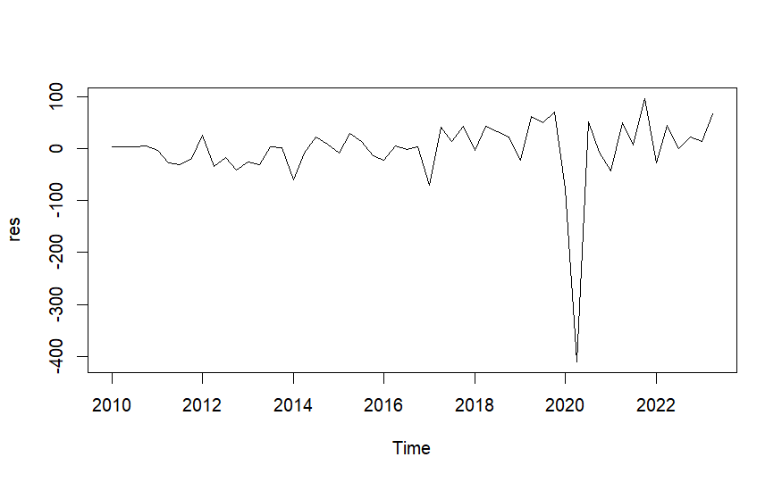

```r
plot(res)
```

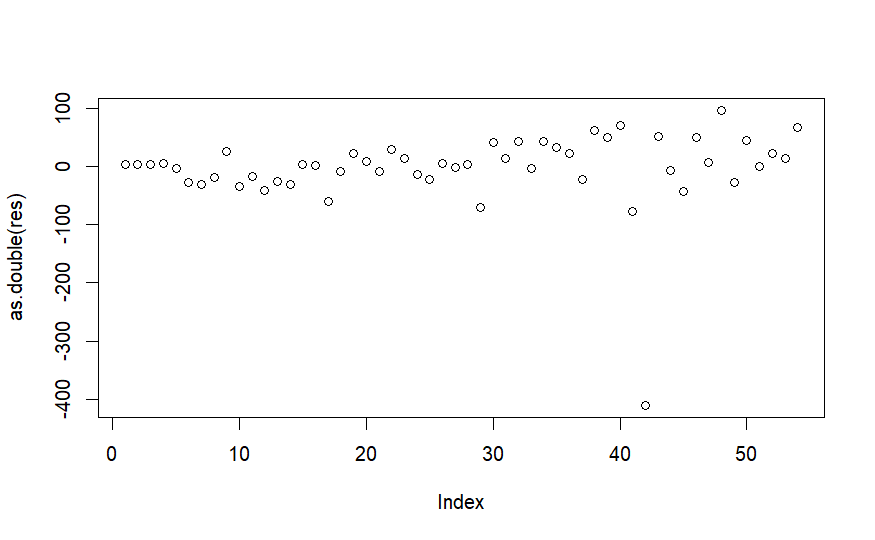

```r
plot(as.double(res))
```

```r
NA
NA
```

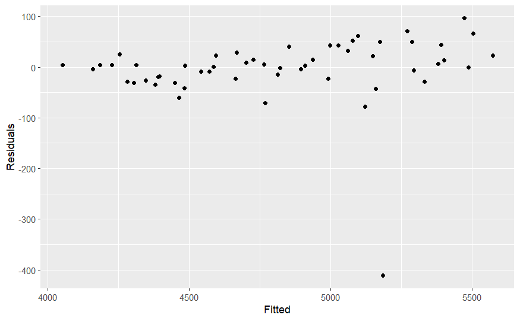

```r
#plot residuals vs fitted - there should be no pattern

# plot(fit$fitted,fit$fitted) # this does not plot correctly because data is stored as time series and R tries to connect the dots

#library(tidyverse)

cbind(Fitted = fitted(fit),
      Residuals=residuals(fit)) %>%
  as.data.frame() %>%
  ggplot(aes(x=Fitted, y=Residuals)) + geom_point()
```

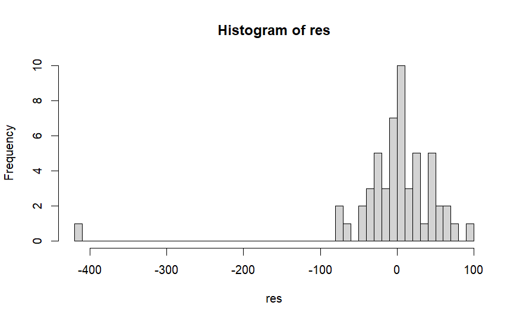

```r
# plot histogram of residuals

hist(res, breaks = 50)
```

```
[1] 42 48
```

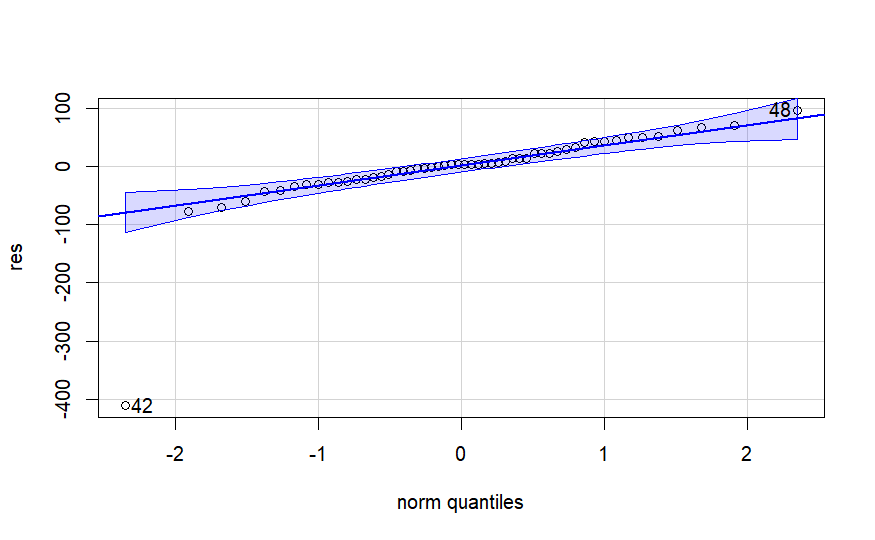

```r
# plot qq plot of residuals

qqPlot(res)
```

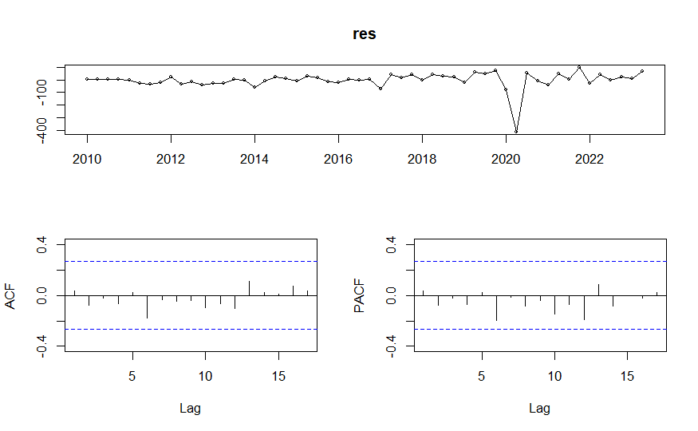

```r
# Plot ACF and PACF

tsdisplay(res)
```

```r
NA
NA
```

# Observations

- The residuals vs fitted values don’t show any patterns which shows they are independent of the model.
- The residuals appear to be normally distributed with a mean of zero. Although, there is one oultier value which may be impacting the model, so more analysis or other models without this value should be considered.
- The ACF and PACF don’t show any significant correlation within the residuals. -Overall, analsysis of the residuals shows this could be a valid model, but will need to be compared to others in order to find the best model.

# Forecast Next 5 periods

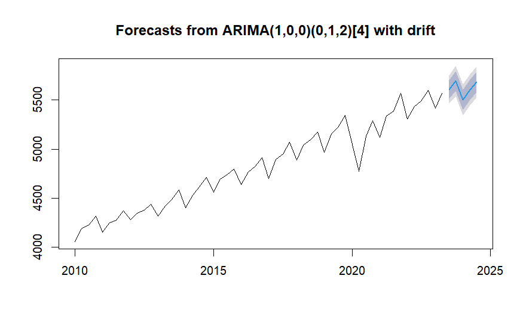

```r
fc1 <- forecast(fit, h=5)

plot(fc1)
```

```r
# show the predicted values

#attributes(fc1)

fc1$mean
```

```
         Qtr1     Qtr2     Qtr3     Qtr4
2023                   5605.912 5693.712
2024 5501.403 5603.557 5681.647
```

```r
# Print accuracy measures of the model

accuracy(fc1)
```

```
                    ME     RMSE      MAE         MPE      MAPE      MASE       ACF1
Training set -2.894346 66.26778 34.63121 -0.09234277 0.7084458 0.2728414 0.03774739
```